# ▒ 주성분분석 ▒

### **0. 환경설정**

```r
# install.packages("factoextra")
library(datasets)
library(factoextra)
library(readxl)
```

**[Define function]** Correlation panel

```r
panel.cor             <- function(x, y){
  usr                 <- par("usr"); on.exit(par(usr))
  par(usr = c(0, 1, 0, 1))
  r                   <- round(cor(x, y), digits = 2)
  txt                 <- paste0("   R = ", r)
  cex.cor             <- 0.9/strwidth(txt)
  text(0.3, 0.3, txt, cex = cex.cor * r)
}
```

**[Define function]** Customize upper panel

```r
upper.panel           <-function(x, y){
  points(x,y, pch = 19, col = "#FC4E07")
}
```

### **1. Data Load**

**(Q) Colinearity가 매우 높다. 차원을 축소할 수 있을까?**

**[데이터 다운로드]**

- C드라이브에 [R_project] 폴더 생성
- [R_project] 폴더에 [DAT] 폴더 생성
- 데이터 스토어에서 샘플데이터(3.아파트_주소기반_주택지역특성시세정보_DB.xlsx)를 “C:/R_project/DAT/”에 다운로드 (https://www.datastore.or.kr/file/detail?id=2c0a9616-4d78-403c-9d77-3db2effb2a74&page=1&viewCount=10&sort=1&order=1&source=1&keyword=%EC%95%84%ED%8C%8C%ED%8A%B8)
- 서울/수도권 및 5대광역시 아파트에 대한 주소테이블 외 4개의 테이블(정보집단)로 구성되며 각각 주택특성정보, 지역특성정보, 가격/신뢰등급/예상회수율정보 테이블로 이루어져 있고, 각 테이블간은 고유키값(NUM)으로 연계되어 있음

**[데이터 호출]**

```r
path                  <- "C:/R_project/DAT/3.아파트_주소기반_주택지역특성시세정보_DB.xlsx"
sheet.names           <- excel_sheets(path)

df1                   <- read_excel(path, sheet.names[1])
df2                   <- read_excel(path, sheet.names[2])
df3                   <- read_excel(path, sheet.names[3])
df4                   <- read_excel(path, sheet.names[4])
data                  <- Reduce(function(x, y) merge(x, y, all=FALSE), list(df1, df2, df3, df4))

data$LAND_ACCESS      <- as.numeric(as.character(data$LAND_ACCESS))
data1                 <- data[complete.cases(data), c(25:27, 48, 49, 85)]

head(data1, 5)
```

```
##   PRIV_AREA PUB_AREA SUM_AREA POPULATION HOUSEHOLD PRICE_GEN
## 1     94.51    66.27   160.78       9584      4577    107000
## 2    126.34    88.60   214.94       9584      4577    124000
## 3    147.31   103.30   250.61       9584      4577    131000
## 4    105.07    13.68   118.75       9584      4577     70600
## 5    140.78   100.84   241.62       9584      4577    131000
```

- PRIV_AREA: 전유면적
- PUB_AREA: 공유면적
- SUM_AREA: 계약면적
- POPULATION: 인구수
- HOUSEHOLD: 가구수
- PRICE_GEN: 일반거래시세

### **2.Scatter Plot & Correlation**

**[상관성 확인]**

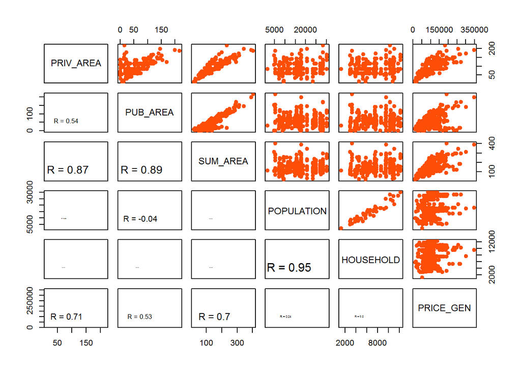

```r
pairs(data1, lower.panel = panel.cor, upper.panel = upper.panel)
```

→ 상관관계가 매우 높은것으로 판단되므로 차원 축소가 필요함

### **3. PCA 수행**

**[Eigen decomposition]** 표준화를 위해 center&scale = T

```r
pca_result_data       <- prcomp(data1, center = T, scale. = T)
```

**[Eigen value]**

```r
data.frame("고유값" = pca_result_data$sdev^2)
```

```
##         고유값
## 1 3.174747e+00
## 2 1.954885e+00
## 3 5.302659e-01
## 4 2.983677e-01
## 5 4.173408e-02
## 6 2.145386e-30
```

**[Eigen Vector]**

```r
data.frame(pca_result_data$rotation)
```

```
##                   PC1         PC2         PC3         PC4         PC5
## PRIV_AREA  -0.4942477 -0.08140219  0.43070031  0.61573043 -0.02781560
## PUB_AREA   -0.4569577 -0.17047987 -0.70972192 -0.20825083  0.07372914
## SUM_AREA   -0.5405604 -0.14499971 -0.18018028  0.21639739  0.02803234
## POPULATION -0.1236063  0.68955758 -0.02410586  0.04097089  0.71201975
## HOUSEHOLD  -0.1279797  0.68206677 -0.17689804  0.07985984 -0.69335100
## PRICE_GEN  -0.4722774  0.05080006  0.49644042 -0.72292710 -0.07277879
##                      PC6
## PRIV_AREA   4.285936e-01
## PUB_AREA    4.578391e-01
## SUM_AREA   -7.789037e-01
## POPULATION  3.295975e-17
## HOUSEHOLD  -1.474515e-16
## PRICE_GEN   6.938894e-18
```

**[누적 기여도]**

```r
summary(pca_result_data)
```

```
## Importance of components:
##                           PC1    PC2     PC3     PC4     PC5       PC6
## Standard deviation     1.7818 1.3982 0.72819 0.54623 0.20429 1.465e-15
## Proportion of Variance 0.5291 0.3258 0.08838 0.04973 0.00696 0.000e+00
## Cumulative Proportion  0.5291 0.8549 0.94332 0.99304 1.00000 1.000e+00
```

→ 각 주성분에 해당하는 고유값과 고유벡터 확인 가능  
→ 평균 고유값(=1) 이상인 제1, 2 주성분 선택  
→ 제1, 2 주성분을 선택 하였을 때 설명력은 약 85.49%임

### **4. Scree Plot**

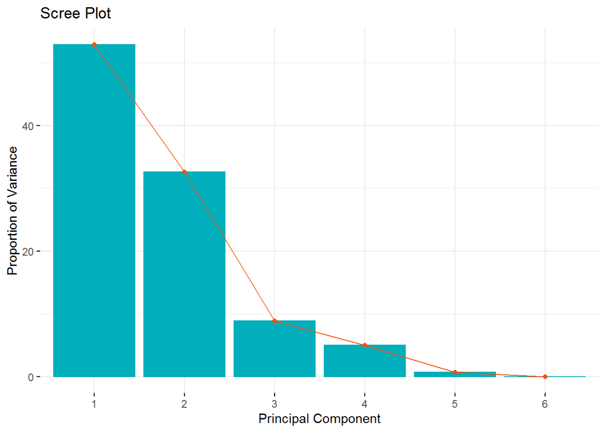

```r
fviz_eig(pca_result_data, main = "Scree Plot", barcolor = "#00AFBB", barfill = "#00AFBB", linecolor = "#FC4E07",
         xlab = "Principal Component", ylab = "Proportion of Variance")
```

→ 기울기가 급감하는 지점을 통해 주성분 개수를 2로 설정

### **5. Biplot Plot**

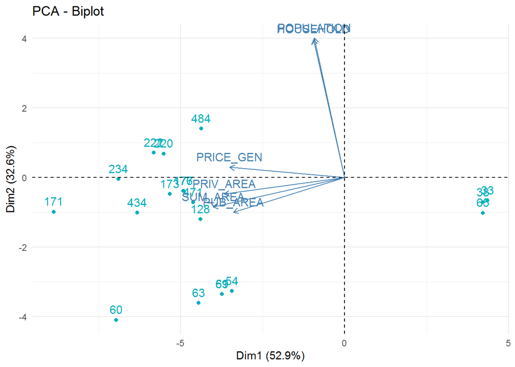

```r
fviz_pca_biplot(pca_result_data, select.ind = list(contrib = 20), col.ind="#00AFBB") +
  theme_minimal()
```

## **6. 주성분 점수 계산**

```r
data1_pc              <- cbind(data1, pc1 = predict(pca_result_data)[, 1], pc2 = predict(pca_result_data)[, 2])
head(data1_pc)
```

```
##   PRIV_AREA PUB_AREA SUM_AREA POPULATION HOUSEHOLD PRICE_GEN        pc1
## 1     94.51    66.27   160.78       9584      4577    107000 -0.1743305
## 2    126.34    88.60   214.94       9584      4577    124000 -1.7278349
## 3    147.31   103.30   250.61       9584      4577    131000 -2.7062986
## 4    105.07    13.68   118.75       9584      4577     70600  1.2007072
## 5    140.78   100.84   241.62       9584      4577    131000 -2.4757411
## 6    140.78   100.84   241.62       9584      4577    131000 -2.4757411
##         pc2
## 1 -1.760841
## 2 -2.088701
## 3 -2.309421
## 4 -1.441589
## 5 -2.254998
## 6 -2.254998
```

**결론**

- Colinearity가 높은 6개의 변수를 차원축소를 통해 2개의 변수변환 하여 전체 변동의 85.49% 설명 가능
- 생성된 주성분은 회귀분석, 군집분석 등의 Input 변수로 활용 가능 함